# Key Data 1

Fall 2026

## Overview

You will calculate some simple metrics for two sites from the Bonita Peak data set. The calculations will largely follow the tutorial from class. In addition to your calculations, you will need to interpret the results and answer some questions.

## Set up

- Load the `tidyverse` library
- Read in the data

```r
# library
library(tidyverse)

# data
bp <- read_csv(here::here("data/bonita_peak.csv"))
```

## Modify data to keep two different sites

- make an object called `data` which only has data from the following two `site_id` values
  - `"MFMaM"`
  - `"MAGaA"`

```r
dat <- bp |>
  filter(site_id == "MFMaM" |
           site_id == "MAGaA")
```

# Calculations

- Complete the following calculations.
- You should save your results for each problem in a new data object.
  - i.e., store the results of problem 1 in an object called `total_rich`, the results for problem 2 as `EPT_rich`, etc.
- When the question asks for you to make a plot, ensure the following
  - The plot has an appropriate title
  - The plot has a descriptive name on the y-axis
  - Your saved plots are a reasonable size
    - After you export the plot, look at it and paste it into your submission document
    - You may need to re-save the plot with different `height` and `width` values.

## Richness

1. Calculate the total richness in your two sites. Make sure to save it as a data object. In addition, make a bar graph of this result and save it as a .png file to your `plots/` folder.

```r
total_rich <- dat |>
  distinct(stream, taxon) |>
  group_by(stream) |>
  summarise(total_rich = n())
total_rich
```

```
# A tibble: 2 × 2
  stream        total_rich
  <chr>              <int>
1 maggie_gulch          28
2 mf_mineral_cr         14
```

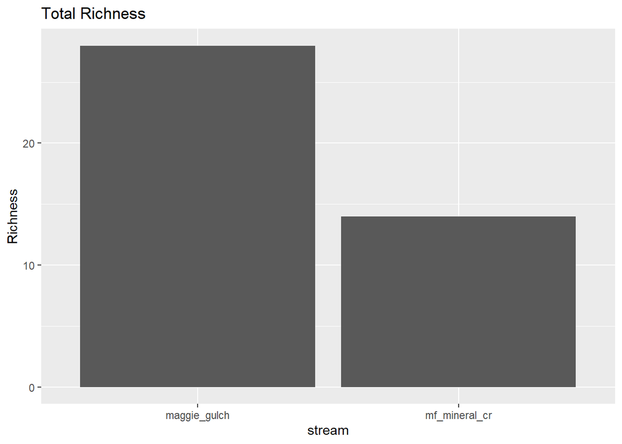

```r
ggplot(total_rich,
       aes(x = stream,
           y = total_rich)) +
  geom_col() +
  labs(title = "Total Richness",
       y = "Richness")
```

2. Calculate the EPT richness in your two sites and save it as a data object.

```r
ept_rich <- dat |>
  filter(order == "Ephemeroptera" |
           order == "Plecoptera" |
           order == "Trichoptera") |>
  distinct(stream, taxon) |>
  group_by(stream) |>
  summarise(EPT_rich = n())

ept_rich
```

```
# A tibble: 2 × 2
  stream        EPT_rich
  <chr>            <int>
1 maggie_gulch        15
2 mf_mineral_cr        6
```

3. Calculate the Richness of the Trichoptera order and save it as an object.

```r
T_rich <- dat |>
  filter(order == "Trichoptera") |>
  distinct(stream, taxon) |>
  group_by(stream) |>
  summarise(T_rich = n())

T_rich
```

```
# A tibble: 2 × 2
  stream        T_rich
  <chr>          <int>
1 maggie_gulch       5
2 mf_mineral_cr      3
```

4. Calculate the richness of the Rhyacophilidae family in your two sites. In addition, make a bar graph of this result and save it as a .png file to your `plots/` folder.

```r
rhya_rich <- dat |>
  filter(family == "Rhyacophilidae") |>
  distinct(stream, taxon) |>
  group_by(stream) |>
  summarise(rhya_rich = n())

rhya_rich
```

```
# A tibble: 2 × 2
  stream        rhya_rich
  <chr>             <int>
1 maggie_gulch          3
2 mf_mineral_cr         2
```

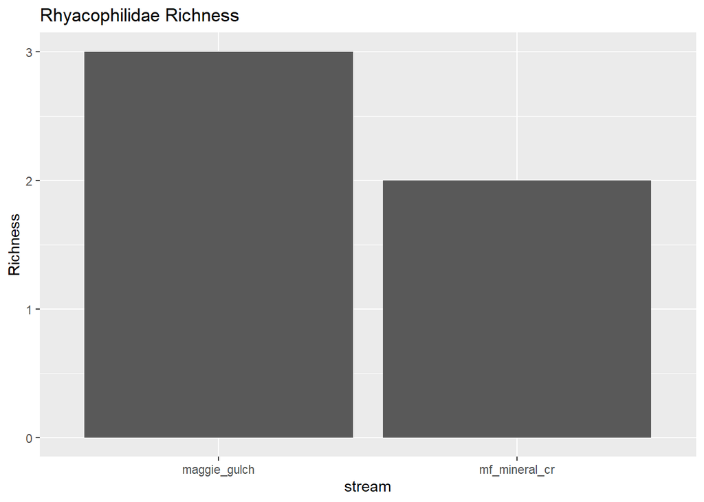

```r
ggplot(rhya_rich,
       aes(x = stream,
           y = rhya_rich)) +
  geom_col() +
  labs(title = "Rhyacophilidae Richness",
       y = "Richness")
```

5. Calculate the per cent of EPT individuals for your two sites and save it as a data object. In addition, make a bar graph of this result and save it as a .png file to your `plots/` folder.

```r
ept_per_n <- dat |>
  filter(order == "Ephemeroptera" |
           order == "Plecoptera" |
           order == "Trichoptera") |>
  group_by(stream, total_count) |>
  summarize(ept_n = sum(count)) |>
  mutate(ept_percent_ind = ept_n / total_count)

ept_per_n
```

```
# A tibble: 2 × 4
# Groups:   stream [2]
  stream        total_count ept_n ept_percent_ind
  <chr>               <dbl> <dbl>           <dbl>
1 maggie_gulch        11952 10032           0.839
2 mf_mineral_cr          47    14           0.298
```

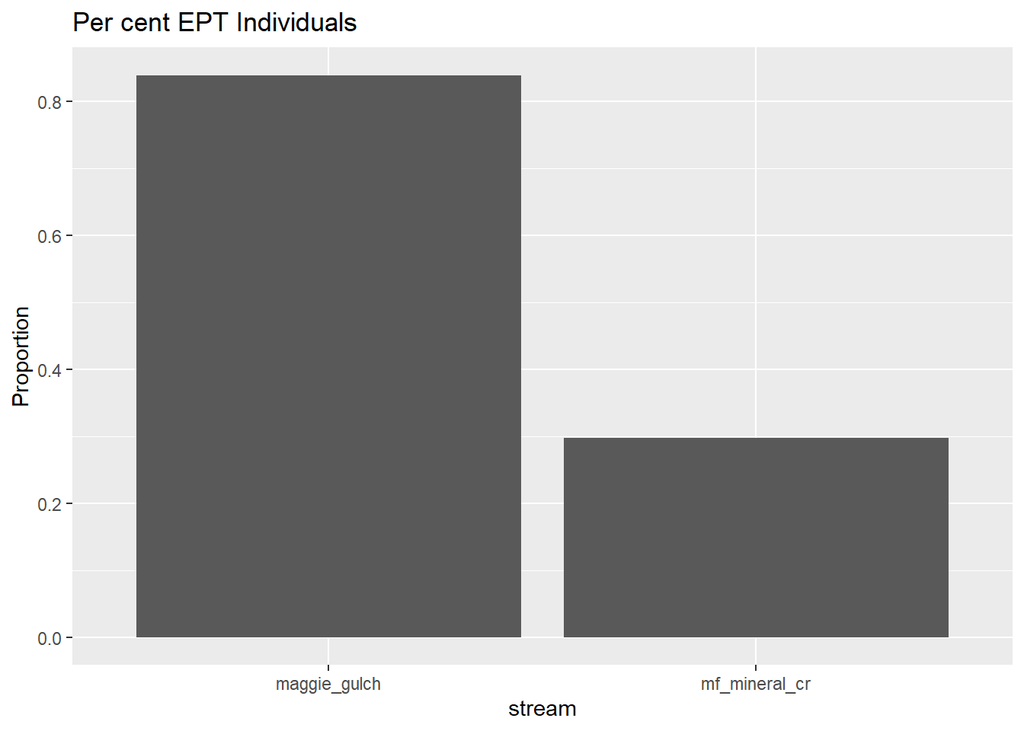

```r
ggplot(ept_per_n,
       aes(x = stream,
           y = ept_percent_ind)) +
  geom_col() +
  labs(title = "Per cent EPT Individuals",
       y = "Proportion")
```

6. Calculate the per cent of individuals which are in the Chironomidae family in your two sites and save it as an object.

```r
chiro_per_n <- dat |>
  filter(family == "Chironomidae") |>
  group_by(stream, total_count) |>
  summarize(chiro_n = sum(count)) |>
  mutate(chiro_percent_ind = chiro_n / total_count)

chiro_per_n
```

```
# A tibble: 2 × 4
# Groups:   stream [2]
  stream        total_count chiro_n chiro_percent_ind
  <chr>               <dbl>   <dbl>             <dbl>
1 maggie_gulch        11952     256            0.0214
2 mf_mineral_cr          47      29            0.617
```

6. Calculate Shannon’s Diversity Index and save it as a data object. In addition, make a bar graph of this result and save it as a .png file to your `plots/` folder.

```r
shannon <- dat |>
  select(stream, taxon, count, total_count) |>
  mutate(pi = count / total_count,
         ln_pi = log(pi),
         pi_ln_pi = pi*ln_pi) |>
  group_by(stream) |>
  summarize(H = -sum(pi_ln_pi))
shannon
```

```
# A tibble: 2 × 2
  stream            H
  <chr>         <dbl>
1 maggie_gulch   1.90
2 mf_mineral_cr  2.00
```

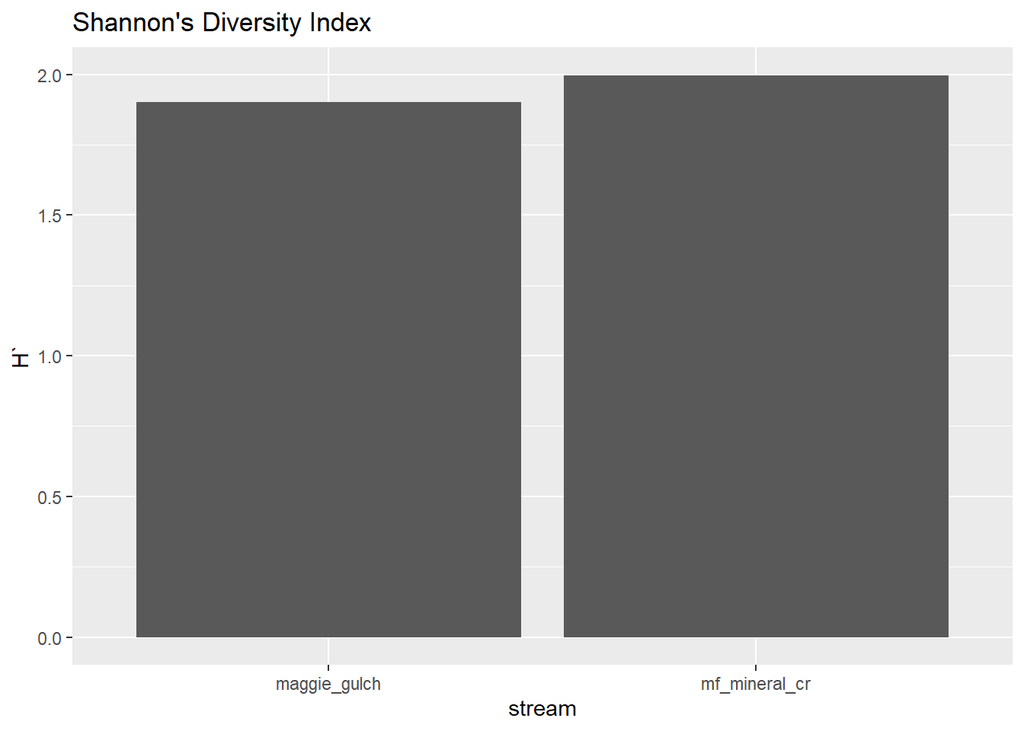

```r
ggplot(shannon,
       aes(x = stream,
           y = H)) +
  geom_col() +
  labs(title = "Shannon's Diversity Index",
       y = "H`")
```

7. Calculate the richness of the predator functional feeding group in your two sites and save it as an object.

```r
pred_rich <- dat |>
    filter(FFG == "predator") |>
    distinct(stream, taxon) |>
    group_by(stream) |>
    summarise(pred_rich = n())
pred_rich
```

```
# A tibble: 2 × 2
  stream        pred_rich
  <chr>             <int>
1 maggie_gulch         10
2 mf_mineral_cr         5
```